# p8105_hw3_pl2811

# There are 35 observations, represents 35 days of trials. There are 1444 variables, other than the week_d variable, we also have week, day_id, day, and activity.1 to activity.1440(as 1440 minutes/ 24 hours of one day).

###Traditional analyses of accelerometer data focus on the total activity over the day. Using your tidied dataset, aggregate accross minutes to create a total activity variable for each day, and create a table showing these totals. Are any trends apparent?

```r
accel_data<-accel_data%>%
    mutate(total = select(.,activity.1:activity.1440) %>%
               rowSums(na.rm = TRUE))

total_act<-select(accel_data,day_id, total)
#since Table is hard to observed any trends , we make plot to see is any trends apparent?
p <- ggplot(data = accel_data, aes(x = day_id, y = total)) +
     geom_line(color = "#00AFBB", size = 1)
accel_data%>%
  ggplot( aes(x=day_id)) +
    geom_density(fill="#69b3a2", color="#e9ecef", alpha=0.8)+
     theme_ipsum()

total_act
```

[output not shown]

#didn’t observe particular trends apparent

###Accelerometer data allows the inspection activity over the course of the day. Make a single-panel plot that shows the 24-hour activity time courses for each day and use color to indicate day of the week. Describe in words any patterns or conclusions you can make based on this graph.

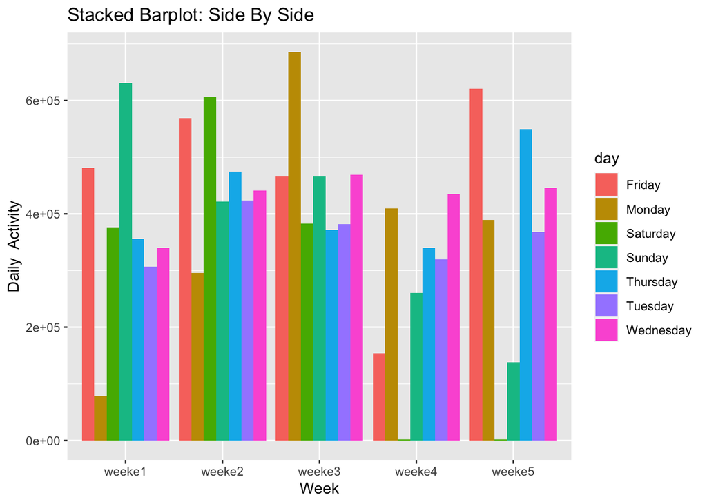

```r
accel_data<-accel_data%>%
    mutate(total = select(.,activity.1:activity.1440) %>%
               rowSums(na.rm = TRUE))

total_act<-select(accel_data,day_id, total)

accel_data<-mutate(accel_data, weeknum = ifelse(day_id < 8, "weeke1",
                                             ifelse(day_id < 15, "weeke2",
                                             ifelse(day_id < 22 , "weeke3",
                                             ifelse(day_id < 29 , "weeke4","weeke5")))))

accel_data %>%
  ggplot(aes( weeknum,total, fill= day))+
  geom_col(position="dodge") +
  labs(title="Stacked Barplot: Side By Side",
        x="Week", y= "Daily  Activity")
```